# sample-matching_IPUMS-NQ_BR

Maita Schade

May 17, 2019

run: *Ctrl+Shift+Enter*. New chunk: *Ctrl+Alt+I*. *Ctrl+Shift+K* to preview the HTML file.

Make sure we’re dealing with a clear space:

```r
rm(list = ls(all = TRUE))
```

```r
country = "MX"
strat1 = "GEO1_MX2015"
strat2 = "URBAN"
NQ_id  = "gp_codigo"
setwd(
  paste0("C:/Users/schadem/Box Sync/LAPOP Shared/working documents/maita/Coordination/IDB Online/Matching process/Data/",country)
)
```

```
The working directory was changed to C:/Users/schadem/Box Sync/LAPOP Shared/working documents/maita/Coordination/IDB Online/Matching process/Data/MX inside a notebook chunk. The working directory will be reset when the chunk is finished running. Use the knitr root.dir option in the setup chunk to ch…
```

```r
library('MatchIt')
library('haven')
library('openxlsx')
library('labelled')
library(zoo)
require('cem')
require(plyr)
require(sampleMatch) #my personal special package for this project.
```

A word or two about feasibility. The only census information we can get is from IPUMS (it seems), and for the countries we are considering, these are the most recent:

country IPUMS census weighted Peru 2007 2017 No Brazil 2010 2010 Yes Chile 2002 2017 No Mexico 2015 2010 Yes (IPUMS intercensal survey) Argentina 2010 2010 No Colombia 2005 2018 Yes

Reading in the sampling data and making necessary updates.

Here, we are using the IPUMS data.

```r
census<- read.csv(
  paste0('C:/Users/schadem/Box Sync/LAPOP Shared/working documents/maita/Coordination/IDB Online/Matching process/Data/',country,'/sample/',country,'_ipums-census_geo.csv')
  )
```

```r
netquest <- read.csv(
  paste0("C:/Users/schadem/Box Sync/LAPOP Shared/working documents/maita/Coordination/IDB Online/Matching process/Data/",
  country,
  "/panel/", country, "_netquest-panel_geo.csv")
)
netquest<-netquest[!duplicated(netquest[NQ_id]),]
```

```r
save.image(paste0(country,"_data_loaded.RData"))
```

```r
#load(paste0(country,"_data_loaded.RData"))
```

We have to recode the various characteristics we have at our disposal.

```r
matching.vars <- c('gend',
                   'age',
                   'ed',
                   'ed_hhh',
                   'emp',
                   'emp_hhh',
                   #'san',
                   'auto',
                   #'cell',
                   #'nbath',
                   'pc',
                   'web',
                   'lightbulb',
                   # 'fridg',
                   # 'motoc',
                   # 'washer',
                   #'insur_hhh',
                   #'walls',
                   'floors',
                   'nrooms',
                   #'nbr',
                   'shower',
                   'tv',
                   'child',
                   # 'hhinc',
                   # 'radio',
                   # 'water',
                   'marst',
                   'pern',
                   'hhtype',
                   'hhh',
                   #'prov', using X and Y instead of province
                   'X',
                   'Y'
                   )
```

Gender: is fine.

```r
census$gend <- census$SEX
netquest$gend <- netquest$p_sexo
```

```r
unique(census$gend)
```

```
[1] 1 2
```

Age: is fine, need to filter these to make sure we exclude too young respondents.

```r
census$age <- mapvalues(census$AGE, from=c(999), to=c(NA))
netquest$age <- netquest$panelistAge
netquest$age[netquest$panelistAge>100] <- 100
```

```r
sort(unique(netquest$age))
```

```
 [1]   9  10  11  12  13  14  15  16  17  18  19  20  21  22  23  24  25  26  27  28  29  30  31  32  33  34  35  36  37  38  39  40  41  42  43  44  45  46  47  48  49  50  51  52  53  54  55  56  57  58  59  60  61
[54]  62  63  64  65  66  67  68  69  70  71  72  73  74  75  76  77  78  79  80  81  82  83  84  85  86  87  88  89  90  91  92  93  94  95  96  98  99 100
```

Education:

```r
census$ed <- rep(NA,length=length(census$EDUCMX))
census$ed[census$EDUCMX== 10] <- 1
census$ed[census$EDUCMX>= 20 & census$EDUCMX<= 29] <- 2
census$ed[census$EDUCMX>=100 & census$EDUCMX<=109] <- 3
census$ed[census$MX2015A_EDLEVEL==2] <- 4
census$ed[census$EDUCMX>=200 & census$EDUCMX<=229] <- 5
census$ed[census$MX2015A_EDLEVEL==3] <- 6
census$ed[census$MX2015A_EDLEVEL%in%c(6,7,8,9)] <- 7
census$ed[census$EDUCMX>=300 & census$EDUCMX<=339] <- 8
census$ed[census$MX2015A_EDLEVEL%in%c(4,5)] <- 9
census$ed[census$EDUCMX>=610 & census$EDUCMX<=619] <- 10
census$ed[census$MX2015A_EDLEVEL%in%c(10,11)] <- 11
census$ed[census$MX2015A_EDLEVEL%in%c(12,13)] <- 12
census$ed[census$MX2015A_EDLEVEL==14] <- 13
#census$ed[census$EDUCMX==999|census$EDUCMX==800] <- NA
netquest$ed <- mapvalues(netquest$MX_education_level_merge,
                         from=c(1,2,3,4,5,6,7,8,9,10,11,12,13,14),
                         to  =c(1,2,3,4,5,6,7,7,8, 9,10,11,12,13)
                         )
```

```r
print(sum(census$EDUCMX==800 | census$EDUCMX==999))
```

```
[1] 715854
```

```r
print(summary(census$ed))
```

```
   Min. 1st Qu.  Median    Mean 3rd Qu.    Max.    NA's
    1.0     4.0     4.0     5.3     6.0    13.0  715854
```

Need head of household, as well

```r
census$ed_hhh <- rep(NA,length=length(census$EDUCMX_HEAD))
census$ed_hhh[census$EDUCMX_HEAD== 10] <- 1
census$ed_hhh[census$EDUCMX_HEAD>= 20 & census$EDUCMX_HEAD<= 29] <- 2
census$ed_hhh[census$EDUCMX_HEAD>=100 & census$EDUCMX_HEAD<=109 & census$MX2015A_EDLEVEL_HEAD<2] <- 3
census$ed_hhh[census$MX2015A_EDLEVEL_HEAD==2] <- 4
census$ed_hhh[census$EDUCMX_HEAD>=200 & census$EDUCMX_HEAD<=229 & census$MX2015A_EDLEVEL_HEAD< 3] <- 5
census$ed_hhh[census$MX2015A_EDLEVEL_HEAD==3] <- 6
census$ed_hhh[census$MX2015A_EDLEVEL_HEAD%in%c(6,7,8,9)] <- 7
census$ed_hhh[census$EDUCMX_HEAD>=300 & census$EDUCMX_HEAD<=339 & census$MX2015A_EDLEVEL_HEAD< 4] <- 8
census$ed_hhh[census$MX2015A_EDLEVEL_HEAD%in%c(4,5)] <- 9
census$ed_hhh[census$EDUCMX_HEAD>=610 & census$EDUCMX_HEAD<=619 & census$MX2015A_EDLEVEL_HEAD<10] <- 10
census$ed_hhh[census$MX2015A_EDLEVEL_HEAD%in%c(10,11)] <- 11
census$ed_hhh[census$MX2015A_EDLEVEL_HEAD%in%c(12,13)] <- 12
census$ed_hhh[census$MX2015A_EDLEVEL_HEAD==14] <- 13
#census$ed_hhh[census$EDUCMX_HEAD==999|census$EDUCMX_HEAD==800] <- NA
netquest$ed_hhh <- mapvalues(netquest$MX_education_level_hhousehold_merge,
                         from=c(1,2,3,4,5,6,7,8,9,10,11,12,13,14),
                         to  =c(1,2,3,4,5,6,7,7,8, 9,10,11,12,13)
                         )
```

```r
print(sum(census$EDUCMX_HEAD==800 | census$EDUCMX_HEAD==999))
```

```
[1] 50286
```

```r
print(summary(census$ed_hhh))
```

```
   Min. 1st Qu.  Median    Mean 3rd Qu.    Max.    NA's
   1.00    4.00    4.00    5.27    6.00   13.00   50286
```

Employment. RECONSIDER ORDERING.

```r
census$emp <- rep(NA,length=length(census$EDUCMX_HEAD))
census$emp[census$MX2015A_EMPSTAT%in%c(10,12,16)] <- 1
census$emp[census$MX2015A_CLASSWK%in%c(4,5)] <- 1     # Trabajo actualmente por cuenta propia
census$emp[census$MX2015A_EMPSTAT%in%c(11,13,14,15)] <- 3
census$emp[census$MX2015A_CLASSWK%in%c(1,2,3)] <- 2   # Trabajo actualmente como empleado
census$emp[census$MX2015A_EMPSTAT== 31] <- 3          # Estudiante (sin trabajar)
census$emp[census$MX2015A_EMPSTAT== 20] <- 4          # Desempleado
census$emp[census$MX2015A_EMPSTAT== 32] <- 5          # Retirado/Pensionista
census$emp[census$MX2015A_EMPSTAT== 34] <- 6          # Incapacitado
census$emp[census$MX2015A_EMPSTAT== 33] <- 7          # Labores del hogar
census$emp[census$MX2015A_EMPSTAT== 35] <- 7          # Did not work--assume that means they did housework
netquest$emp <- mapvalues(netquest$MX_laboral_situation,
       from=c(1,2,3,4,5,6,7,8,9),
       to=  c(1,2,3,4,4,5,5,6,7))
```

```r
unique(census$emp)
```

```
[1]  2  7  3 NA  1  5  6  4
```

Employment of head of household: see above

```r
census$emp_hhh <- rep(NA,length=length(census$EDUCMX_HEAD))
census$emp_hhh[census$MX2015A_EMPSTAT_HEAD%in%c(10,12,16)] <- 1
census$emp_hhh[census$MX2015A_CLASSWK_HEAD%in%c(4,5)] <- 1     # Trabajo actualmente por cuenta propia
census$emp_hhh[census$MX2015A_EMPSTAT_HEAD%in%c(11,13,14,15)] <- 3
census$emp_hhh[census$MX2015A_CLASSWK_HEAD%in%c(1,2,3)] <- 2   # Trabajo actualmente como empleado
census$emp_hhh[census$MX2015A_EMPSTAT_HEAD== 31] <- 3          # Estudiante (sin trabajar)
census$emp_hhh[census$MX2015A_EMPSTAT_HEAD== 20] <- 4          # Desempleado
census$emp_hhh[census$MX2015A_EMPSTAT_HEAD== 32] <- 5          # Retirado/Pensionista
census$emp_hhh[census$MX2015A_EMPSTAT_HEAD== 34] <- 6          # Incapacitado
census$emp_hhh[census$MX2015A_EMPSTAT_HEAD== 33] <- 7          # Labores del hogar
census$emp_hhh[census$MX2015A_EMPSTAT_HEAD== 35] <- 7          # Did not work--assume that means they did housework
netquest$emp_hhh <- mapvalues(netquest$MX_laboral_situation_hhousehold,
       from=c(1,2,3,4,5,6,7,8,9),
       to=  c(1,2,3,4,4,5,5,6,7))
```

```r
unique(census$emp_hhh)
```

```
[1]  2  1  5  7  6 NA  4  3
```

Auto

```r
census$auto <- mapvalues(census$AUTOS,
        from=c(0,7,8,9),
        to=  c(2,1,NA,NA))
netquest$auto <- mapvalues(netquest$MX_NSE_cars,
       from=c(1,2,3,4),
       to=  c(2,1,1,1))
```

```r
unique(netquest$auto)
```

```
[1]  1  2 NA
```

Computer?

```r
census$pc <- mapvalues(census$COMPUTER,
                       from=c(0,1,2,9),
                       to=c(NA,2,1,NA))
netquest$pc <- mapvalues(netquest$MX_NSE_computer,
                         from=c(1,2,3),
                         to  =c(2,1,1)
                         )
```

```r
unique(census$pc)
```

```
[1]  1  2 NA
```

Internet?

```r
census$web <- mapvalues(census$INTERNET, from=c(0,1,2,9), to=c(NA,2,1,NA))
netquest$web <- mapvalues(netquest$MX_NSE_internet_at_home, from = c(1,2), to=c(1,2))
```

```r
summary(netquest$MX_NSE_internet_at_home)
```

```
   Min. 1st Qu.  Median    Mean 3rd Qu.    Max.    NA's
   1.00    1.00    1.00    1.16    1.00    2.00  283622
```

Lightbulbs?

```r
census$lightbulb <- rep(NA,length=length(census$MX2015A_LIGHTBULB))
census$lightbulb[census$MX2015A_LIGHTBULB>= 0 & census$MX2015A_LIGHTBULB<= 5] <- 1
census$lightbulb[census$MX2015A_LIGHTBULB>= 6 & census$MX2015A_LIGHTBULB<=10] <- 2
census$lightbulb[census$MX2015A_LIGHTBULB>=11 & census$MX2015A_LIGHTBULB<=15] <- 3
census$lightbulb[census$MX2015A_LIGHTBULB>=16 & census$MX2015A_LIGHTBULB<=20] <- 4
census$lightbulb[census$MX2015A_LIGHTBULB>=21 & census$MX2015A_LIGHTBULB<=90] <- 5
netquest$lightbulb <- netquest$MX_NSE_lights
```

```r
unique(census$lightbulb)
```

```
[1]  2  4  1  3  5 NA
```

Floors of dwelling (there is some ambiguity here between the vinilicos and laminadas de vinil) PE_NSE_pavement : 1 Tierra / Otro material (arena y tablones sin pulir) 2 Cemento sin pulir o pulido / Madera (entablados) / tapizón 3 Losetas / terrazos, mayólicas, cerámicos, vinílicos, mosaico o similares 3 Laminado tipo madera, láminas asfálticas o similares 4 Parquet o madera pulida y similares; porcelanato, alfombra, mármol

```r
#When going numeric, must replace NA with the average
census$floors <- mapvalues(census$MX2015A_FLOOR,
        from=c(1, 2, 3, 8, 9),
        to=  c(1, 1, 2,NA,NA))
netquest$floors <- mapvalues(netquest$MX_NSE_pavement,
        from=c(1, 2),
        to=  c(1, 2))
```

```r
unique(netquest$floors)
```

```
[1]  2  1 NA
```

Number of rooms

```r
census$nrooms <- rep(NA,length=length(census$MX2015A_ROOMS))
census$nrooms[census$MX2015A_ROOMS<7] <- census$MX2015A_ROOMS[census$MX2015A_ROOMS<7]
census$nrooms[census$MX2015A_ROOMS>=7 & census$MX2015A_ROOMS<=20] <- 7
netquest$nrooms <- netquest$MX_NSE_rooms
```

```r
unique(census$nrooms)
```

```
[1]  4  3  2  5  7  1  6 NA
```

Shower?

```r
census$shower <- rep(NA,length=length(census$MX2015A_SHOWER))
census$shower[census$MX2015A_SHOWER<3] <-  census$MX2015A_SHOWER[census$MX2015A_SHOWER<3]
netquest$shower <- netquest$MX_NSE_shower
```

```r
unique(netquest$shower)
```

```
[1]  1 NA  2
```

Number of TVs

```r
census$tv[census$MX2015A_TV%in%c(1,2)] <- census$MX2015A_TV[census$MX2015A_TV%in%c(1,2)]
netquest$tv <- mapvalues(netquest$MX_NSE_tv,
                         from=c(1,2,3,4),
                         to  =c(2,1,1,1)
                         )
```

```r
unique(census$tv)
```

```
[1]  1  2 NA
```

Walls of dwelling PE_NSE_walls: 1 Estera 2 Madera/ Piedra con barro/ Quincha (caña con barro)/ Tapia/ Adobe 3 Piedra o sillar con cal o cemento 4 Ladrillo o bloque de cemento

Children

```r
census$child<-rep(NA, length=length(census$NCHILD))
census$child[census$NCHILD<=7] <- census$NCHILD[census$NCHILD<=7]
census$child[census$NCHILD>7] <- 7
netquest$child <- netquest$number_P3
netquest$child[netquest$P3==2] <- 0
```

```r
unique(netquest$child)
```

```
[1]  0  2  3  1  5  7  4  6 NA
```

Marital status: need P1 from Netquest!

```r
census$marst <- mapvalues(census$MARST,
                          from=c(1,2,3,4,9),
                          to  =c(1,4,2,3,NA)
                          )
netquest$marst <- mapvalues(netquest$P1,
                          from=c(1,2,3,4),
                          to  =c(1,4,2,3)
                          )
```

```r
unique(netquest$marst)
```

```
[1]  4  1  2  3 NA
```

number of persons in household

```r
census$pern <- census$PERSONS
netquest$pern <- netquest$P2
```

```r
unique(census$pern)
```

```
 [1]  4  2  3  1  5  6 11  8 29  7  9 10 13 12 17 14 18 19 15 16 21 25 28 22 20 24 26 23 27 30 35 34 38
```

type of household

```r
census$hhtype <- mapvalues(census$HHTYPE,
                          from=c(1,5,6,7,8,2,3,4,6,11,99, 0),
                          to  =c(1,5,5,6,6,2,4,3,5, 0, 0,NA)
                          )
netquest$hhtype <- mapvalues(netquest$P8,
                          from=c(1,2,3,4,5,6,7,99),
                          to  =c(1,5,6,2,4,3,5, 0)
                          )
```

head of household?

```r
census$hhh <- rep(NA,length=length(census$RELATE))
census$hhh[census$RELATE>1] <- 2
census$hhh[census$RELATE==1] <- 1
netquest$hhh <- mapvalues(netquest$P12,
                          from=c(1,2,3),
                          to  =c(1,2,1)
                          )
```

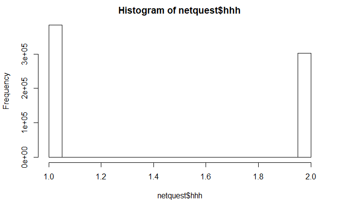

```r
hist(netquest$hhh)
```

Give ID to both datasets, so we can go back to IDs when necessary

```r
census$id <- seq(dim(census)[1])
netquest$id <- seq(dim(netquest)[1])
```

If we do some non-numeric matching, we’d want to adjust the labels/levels.

```r
panel <- to_factor(netquest[append(matching.vars, c('id'))],
                   drop_unused_labels = TRUE)
panel['Fakeid'] <- netquest[[NQ_id]]
panel <- panel[panel$age>17,]
panel <- na.omit(panel)
summary(panel)
```

```
      gend            age               ed             ed_hhh            emp           emp_hhh           auto             pc             web          lightbulb         floors          nrooms          shower
 Min.   :1.000   Min.   : 18.00   Min.   : 1.000   Min.   : 1.000   Min.   :1.000   Min.   :1.000   Min.   :1.000   Min.   :1.000   Min.   :1.000   Min.   :1.000   Min.   :1.000   Min.   :1.000   Min.   :1.000
 1st Qu.:1.000   1st Qu.: 22.00   1st Qu.: 8.000   1st Qu.: 7.000   1st Qu.:2.000   1st Qu.:1.000   1st Qu.:1.000   1st Qu.:1.000   1st Qu.:1.000   1st Qu.:2.000   1st Qu.:1.000   1st Qu.:3.000   1st Qu.:1.000
 Median :2.000   Median : 27.00   Median : 9.000   Median : 9.000   Median :2.000   Median :2.000   Median :1.000   Median :1.000   Median :1.000   Median :2.000   Median :2.000   Median :4.000   Median :1.000
 Mean   :1.514   Mean   : 29.19   Mean   : 9.163   Mean   : 8.941   Mean   :2.564   Mean   :2.044   Mean   :1.422   Mean   :1.264   Mean   :1.145   Mean   :2.413   Mean   :1.655   Mean   :3.883   Mean   :1.089
 3rd Qu.:2.000   3rd Qu.: 34.00   3rd Qu.:11.000   3rd Qu.:11.000   3rd Qu.:3.000   3rd Qu.:2.000   3rd Qu.:2.000   3rd Qu.:2.000   3rd Qu.:1.000   3rd Qu.:3.000   3rd Qu.:2.000   3rd Qu.:5.000   3rd Qu.:1.000
 Max.   :2.000   Max.   :100.00   Max.   :13.000   Max.   :13.000   Max.   :7.000   Max.   :7.000   Max.   :2.000   Max.   :2.000   Max.   :2.000   Max.   :5.000   Max.   :2.000   Max.   :7.000   Max.   :2.000

       tv            child            marst            pern            hhtype           hhh              X                 Y               id                      Fakeid
 Min.   :1.000   Min.   :0.0000   Min.   :1.000   Min.   : 1.000   Min.   :0.000   Min.   :1.000   Min.   :-116.89   Min.   :14.64   Min.   :     1   000015a075118118:     1
 1st Qu.:1.000   1st Qu.:0.0000   1st Qu.:1.000   1st Qu.: 3.000   1st Qu.:4.000   1st Qu.:1.000   1st Qu.:-102.01   1st Qu.:19.34   1st Qu.:171643   00002073f6b926c8:     1
 Median :1.000   Median :0.0000   Median :1.000   Median : 4.000   Median :5.000   Median :1.000   Median : -99.25   Median :19.67   Median :342809   0000260bb21b7995:     1
 Mean   :1.048   Mean   :0.7572   Mean   :2.309   Mean   : 4.168   Mean   :3.947   Mean   :1.409   Mean   :-100.32   Mean   :21.38   Mean   :343281   000045505f1d287c:     1
 3rd Qu.:1.000   3rd Qu.:1.0000   3rd Qu.:4.000   3rd Qu.: 5.000   3rd Qu.:5.000   3rd Qu.:2.000   3rd Qu.: -98.95   3rd Qu.:21.96   3rd Qu.:515179   000054183671061d:     1
 Max.   :2.000   Max.   :7.0000   Max.   :4.000   Max.   :15.000   Max.   :6.000   Max.   :2.000   Max.   : -86.91   Max.   :32.44   Max.   :686957   000070373cd68752:     1
                                                                                                                                                      (Other)         :380567
```

ADJUST FOR COUNTRY!

```r
census.proc <- to_factor(census[append(matching.vars,c(
  strat2,
  'PERWT',
  strat1,'id'))], drop_unused_labels = TRUE)
census.proc <- census.proc[census.proc$age>17,]
census.proc <- na.omit(census.proc)
census.proc <- census.proc[order(census.proc[strat1],census.proc[strat2]),]
summary(census.proc)
```

```
      gend            age              ed             ed_hhh            emp           emp_hhh           auto             pc             web          lightbulb         floors          nrooms          shower
 Min.   :1.000   Min.   : 18.0   Min.   : 1.000   Min.   : 1.000   Min.   :1.000   Min.   :1.000   Min.   :1.000   Min.   :1.000   Min.   :1.000   Min.   :1.000   Min.   :1.000   Min.   :1.000   Min.   :1.000
 1st Qu.:1.000   1st Qu.: 27.0   1st Qu.: 4.000   1st Qu.: 4.000   1st Qu.:2.000   1st Qu.:2.000   1st Qu.:1.000   1st Qu.:2.000   1st Qu.:2.000   1st Qu.:1.000   1st Qu.:1.000   1st Qu.:3.000   1st Qu.:1.000
 Median :2.000   Median : 38.0   Median : 6.000   Median : 4.000   Median :3.000   Median :2.000   Median :2.000   Median :2.000   Median :2.000   Median :1.000   Median :1.000   Median :3.000   Median :1.000
 Mean   :1.523   Mean   : 41.4   Mean   : 5.901   Mean   : 5.287   Mean   :4.076   Mean   :3.292   Mean   :1.623   Mean   :1.779   Mean   :1.793   Mean   :1.566   Mean   :1.271   Mean   :3.604   Mean   :1.472
 3rd Qu.:2.000   3rd Qu.: 53.0   3rd Qu.: 9.000   3rd Qu.: 6.000   3rd Qu.:7.000   3rd Qu.:6.000   3rd Qu.:2.000   3rd Qu.:2.000   3rd Qu.:2.000   3rd Qu.:2.000   3rd Qu.:2.000   3rd Qu.:5.000   3rd Qu.:2.000
 Max.   :2.000   Max.   :100.0   Max.   :13.000   Max.   :13.000   Max.   :7.000   Max.   :7.000   Max.   :2.000   Max.   :2.000   Max.   :2.000   Max.   :5.000   Max.   :2.000   Max.   :7.000   Max.   :2.000
       tv            child           marst            pern            hhtype          hhh              X                 Y             URBAN           PERWT        GEO1_MX2015          id
 Min.   :1.000   Min.   :0.000   Min.   :1.000   Min.   : 1.000   Min.   :0.00   Min.   :1.000   Min.   :-116.89   Min.   :14.64   Min.   :1.000   Min.   :  2.0   Min.   : 1.00   Min.   :       1
 1st Qu.:1.000   1st Qu.:0.000   1st Qu.:2.000   1st Qu.: 3.000   1st Qu.:4.00   1st Qu.:1.000   1st Qu.:-101.28   1st Qu.:18.40   1st Qu.:1.000   1st Qu.:  4.0   1st Qu.:12.00   1st Qu.: 2939203
 Median :1.000   Median :1.000   Median :4.000   Median : 4.000   Median :4.00   Median :2.000   Median : -98.99   Median :19.57   Median :2.000   Median :  6.0   Median :16.00   Median : 5726516
 Mean   :1.106   Mean   :1.336   Mean   :3.178   Mean   : 4.564   Mean   :3.95   Mean   :1.599   Mean   : -99.11   Mean   :20.30   Mean   :1.579   Mean   : 11.2   Mean   :17.86   Mean   : 5737037
 3rd Qu.:1.000   3rd Qu.:2.000   3rd Qu.:4.000   3rd Qu.: 6.000   3rd Qu.:5.00   3rd Qu.:2.000   3rd Qu.: -97.04   3rd Qu.:21.02   3rd Qu.:2.000   3rd Qu.: 10.0   3rd Qu.:24.00   3rd Qu.: 8591303
 Max.   :2.000   Max.   :7.000   Max.   :4.000   Max.   :38.000   Max.   :6.00   Max.   :2.000   Max.   : -86.91   Max.   :32.44   Max.   :2.000   Max.   :934.0   Max.   :32.00   Max.   :11344365
```

Try stratified sampling, with my custom package.

```r
n <- 1200
#require('sampling')
set.seed(111)
target  <- strat_weight_sample(census.proc,c(strat1,strat2),'PERWT',n)
```

```
PERWT ~ GEO1_MX2015 + URBAN
<environment: 0x00000248f6b67070>
```

```r
#add Fakeid, so we can keep those from the panel in the matching set
target['Fakeid'] <- as.integer(rep(999999, length(target$age)))
```

Making sure this stratification worked…

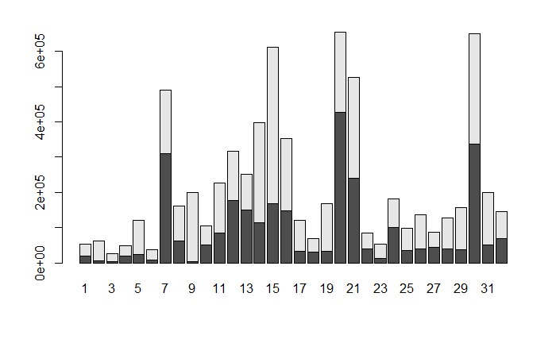

```r
barplot(table(census.proc[[strat2]], census.proc[[strat1]]))
```

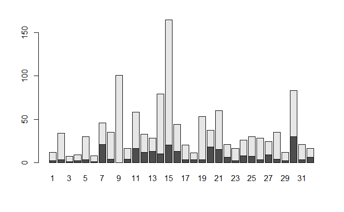

```r
barplot(table(target[[strat2]], target[[strat1]]))
```

Add a treatment into it:

```r
panel['treat'] <- rep(0,length(panel$age))
target['treat'] <- rep(1,length(target$age))
```

Now join this data together:

```r
panel['treat'] <- rep(0,length(panel$age))
target['treat'] <- rep(1,length(target$age))
#simple_target['treat'] <- rep(1,length(simple_target$age))
```

```r
alldata<-rbind(panel,target[names(panel)])
```

```
invalid factor level, NA generated
```

```r
#jointId will be the sequence number in the joint dataframe -- MAY NOT NEED THIS?
alldata$jointId <- seq(dim(alldata)[1])
rownames(alldata) <- alldata$jointId
unique(table(alldata$id))
```

```
[1] 1 2
```

```r
# add a level to the alldata fakeid to accommodate the target
levels(alldata$Fakeid) <- c(levels(alldata$Fakeid),999999)
alldata$Fakeid[is.na(alldata$Fakeid)]<-999999
```

# for the methods that require numeric approximation

```r
alldata_num<-data.frame(lapply(alldata, as.numeric))
```

```r
summary(alldata_num)
```

[output not shown]

Now the matching begins. This is using the MatchIt package as we are used to…

```r
matching.form <- as.formula(paste0("treat ~ ", paste(matching.vars, collapse=' + ')))
```

We’ll have to repeat this process (at least for everything except PS), since the memory can’t deal with all of this. * start empty dataframe initialized with target IDs * make a copy of the data to alter * for each i in range: + run the matching + store the matched IDs + store some overall metrics about the match + reduce the panel data * return the match objects

```r
matchRatio <- function(data, metric, n, exact = c()){

  # assign the dataframe to hold the matching results
  df <- data.frame(matrix(ncol=1, nrow=sum(data$treat==1)))
  names(df) <- c("targetId")
  df$targetId <- data$id[data$treat==1]

  # assign the object to hold all the matching information
  matches <- vector("list",n)

  # make a copy of the passed-in data
  data.copy <- data.frame(data)


  # loop over the number of respondents per target
  # if there are issues, can I relax the age groups?
  for(i in 1:n){
    print(paste('i = ',to_character(i)))
    m <- matchit(matching.form,
                 data = data.copy, exact=exact, method = "nearest", distance = metric)

    try({matches[[i]] <- m
        targetids <- data.copy[row.names(m$match.matrix), "id"]
        panelids <- as.data.frame(data.copy[m$match.matrix,"Fakeid"])
        names(panelids)<-c("panelId")
        panelids['targetId']<-targetids
        df <- merge(x=df, y=panelids, by="targetId", all.x = TRUE, suffixes=c("",to_character(i)))
        } #... maybe merge instead might be safer?
    )

    controls <- match.data(m, group='control')
    data.copy <- data.copy[!data.copy$jointId %in% controls$jointId,] # not relying on rownames

  }
  return(list("ids"=df, "matches"=matches))
}
```

```r
matches.cem_mah = matchRatio(alldata_num, "mahalanobis", 1, exact = c("age_group","gend"))
```

```
[1] "i =  1"
```

Save the id’s of the matches to a file, so I don’t lose them–just in case

```r
tmp <- matches.cem_mah$ids
# attaching NQ panel code
tmp[NQ_id] <- merge(x = matches.cem_mah$ids,
                    y = alldata[alldata$treat==0, c("Fakeid",'id')],
                    by.x = "panelId",
                    by.y = "id")[["Fakeid"]]
# attaching census identification, just in case!
tmp[c("SERIAL","PERNUM")] <- merge(x = matches.cem_mah$ids,
                                   y = census[c("SERIAL","PERNUM","id")],
                                   by.x = 'targetId',
                                   by.y = 'id')[c("SERIAL","PERNUM")]
write.csv(x=tmp[c("targetId",NQ_id, "SERIAL","PERNUM")], file=paste0("C:/Users/schadem/Box Sync/LAPOP Shared/working documents/maita/Coordination/IDB Online/Matching process/Data/",country,"/panel/matches_cem-mah.csv"))
```

```r
summary(tmp)
```

[output not shown]